# README

## Discrete time logistic model for population growth.

#### Notations:

- $N_t$ : Population size at time $t$
- $B_t$ : Total number of births in interval $(t, t+1)$
- $D_t$ : Total number of deaths in interval $(t, t+1)$
  - In this model $D_t = N_t$.
- $b_t = B_t / N_t$ := Per capita birth rate (:= expected litter size per individual ; see last section)
- $d_t = D_t / N_t$ := Per capita death rate
- $R_t = 1 + b_t - d_t$ := Growth rate
- $X_t = N_t/K$
- Note: $N_t, B_t, D_t, b_t, R_t, X_t > 0$
- **NBS** := No biological sense.

This is one of the simplest(!) model due to many underlying assumptions.

#### Logistic model:

If we assume there are limited resources in the closed ecosystem, then larger the population, more the fights for resources; resulting in the high number of deaths and less number of births. This indicates that the growth rate is a decreasing function of population size.

Let’s assume simple linear relation between $R_t$ and $N_t$:
$$R_t =
R_m (1 - N_t/K)$$
Here, at $N_t = 0$, $R_t$ attains the non-negative maxima denoted by $R_m$ and in this model N_t can not grow beyond a point when $R_t = 0$, here $K$ is maximum value $N_t$ can attain.

Therefore we get the following population growth equation:

$$N_{t+1} = R_m N_t (1 - N_t / K)$$
We divide both side by $K$ to normalize $N_t$ to bound it in the interval $[0, 1]$. And let $X_t = N_t/ K$ : = Normalized population. So, we get:
$$X_{t+1} = R_m X_t
(1-X_t)$$

Note :

- For this model we have to restrict $0 \le R_m \le 4$ otherwise $0 \le X_t \le 1$ may not hold for all $t$, and hence **NBS**.
- From assumption of Non overlapping generations we have $b_t = R_t$
- Due to mean field assumption we don’t have to restrict $N_t$ to $\mathbb{Z}_{\ge 0}$ for sake of biological meaning.

#### Example Trajectories:

- you can play with values of R_m to check for different R_m.

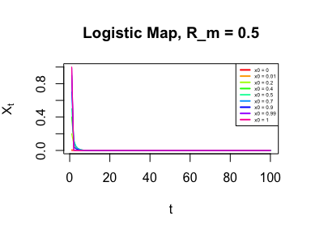

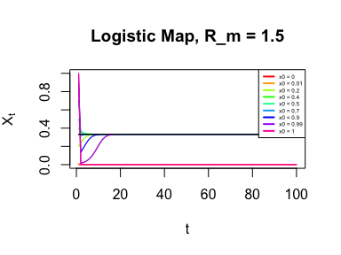

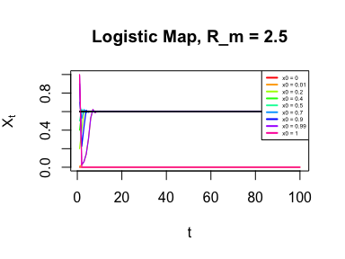

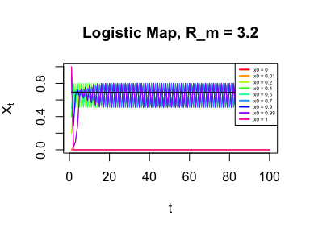

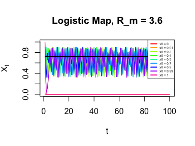

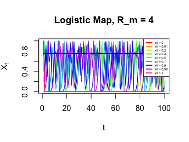

```r
plot_each_R_m(R_m_list = c(0.5, 1.5, 2.5, 3.2, 3.6, 4))
```

#### Equilibrium/ fixed point : $X^*$

Population size, if attained, stays constant over all the following generations.

> Let **E** be state space consisting of all population sizes, and **f** be evolution function (i.e. flow) then $X_{t+1} = f(X_t)$. And $X^*$ is a fixed point/equilibrium if $X^* = f(X^*)$.

$$\begin{aligned}
& X^*= R_m X^*(1 - X^*) \\
& \\
\text{Positive Solutions:}\\
& \text{a) } X^* = 0 & \text{for } R_m \in [ 0, 4] \\
& \text{b) } X^* = 1 - \frac{1}{R_m} & \text{for } R_m \in [1,
4]
\end{aligned}$$

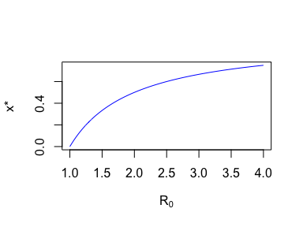

```r
plot_eqb_curve()
```

### Stability of equilibrium:

Small perturbation to $X^*$ stays small and eventually dies out over time.

> **Asymptotically stable:**

> Let $X^*$ be fixed point of **f**, if $\forall \epsilon \gt 0$ , $\exists \delta \gt 0$ s.t.
> $$|X_0 - X^* | \lt \delta \implies |X_n
> - X^*| \lt \epsilon, \forall n \ge 0$$

> and $\exists \delta_0 \gt 0$ s.t
> $$|X_0 - X^* | \lt \delta_0 \implies X_n
> \rightarrow X^*$$

> **Linear stability test:**

> Let $f : E \rightarrow E$ be evolution function where $E$ is $\mathbb{R}^+$. And let $f$ be $C^1$ near fixed point $X^*$, then
> $$\begin{aligned} |f'( X^* ) | \lt 1 &
> \implies X^* \text{ is asymptotically stable. } \\ |f'(X^) | \gt 1
> & \implies X^* \text{ is unstable.} \end{aligned}$$

#### Bifurcation:

> **Attractor points of**$\{X_n\}$ : we plot subsequential limit points of sequence of population size time series $X_n$. for given $R_m$ set of attractor points could be single point where the orbit converges, finitely many points on a periodic cycle, or a continuum/Cantor-like set under chaos.

> **Bifurcation diagram (discrete case)** : For each $R_m$ we plotted last $200$ values of $X_t$. i.e.values from $\phi_{800}(0.1; R_m)$ to $\phi_{1000}(0.1; R_m)$ against each $R_m$.
> - you can play with values of $x_0$

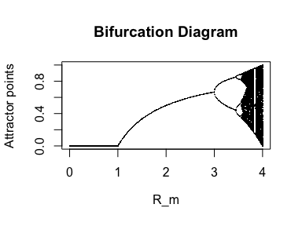

```r
Plot_Bifurcation(x_0 = 0.1)
```

#### Determinism, Robustness

- Logistic model is completely deterministic. No stochastic elements involved (`This is not so maybe concluded from last section)`.
- Model is robust except at the bifurcation points. (trivial)
  - Robustness (or its loss, at a bifurcation) is what early-warning signals detect.

#### Predictability

Check `predictability of model.R` for simulation.

- we have computationally checked the for error values $\delta(0) = 0.1, 0.01, 0.00001$
  - you can check for multiple values by just changing `error` vector in the function input.
  - `Plot_error_trajectories(dynamic function, initial states, parameter values, time step, error vector)` - you can change input variables and play around with any discrete time dynamic function to see how they respond to errors.
- Evolution of error in discrete logistic model:
  - here $\delta(t) \text{ is relabeld as } E_t$

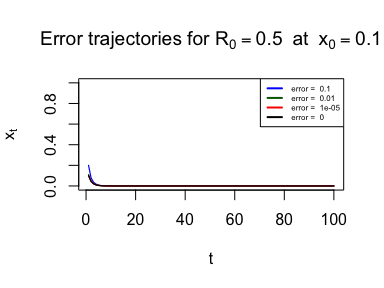

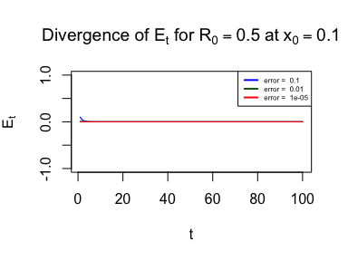

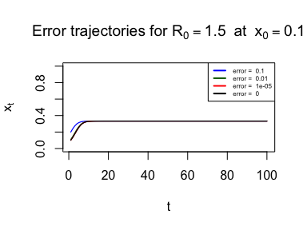

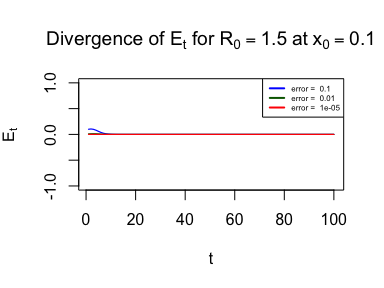

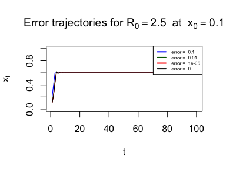

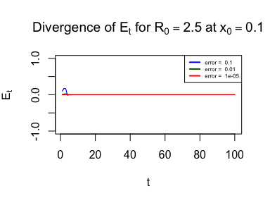

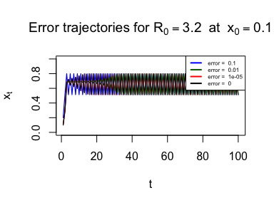

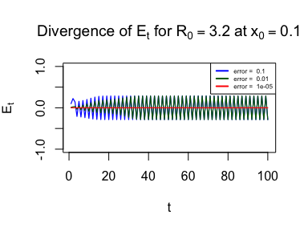

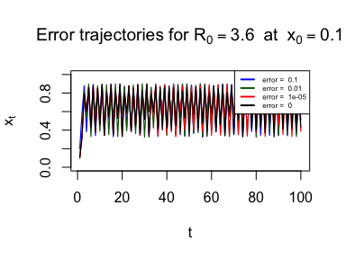

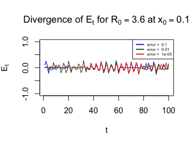

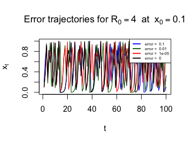

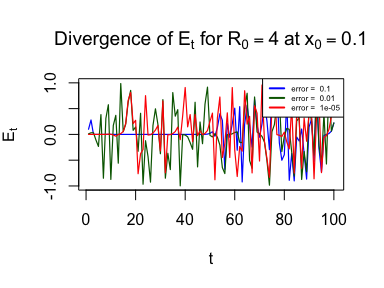

```r
Plot_error_trajectories(X_0_list = c(0.1), R_m_list = c(0.5, 1.5, 2.5, 3.2, 3.6, 4), t= 1:100, eps= c(0.1, 0.01, 0.00001))
```

#### Observation:

- Whenever we take $R_t$ linearly decreasing with increasing $N_t$, values of $R_t$ lands on many fractional numbers or even irrational numbers (but computationally impossible). These fractional values of $R_t$ invokes non-integer population sizes; which makes No biological sense as population must be an integer. And therefore we need to summon randomness to handle it.
- We can not avoid randomness even when formulation is completely deterministic.
- Let per capita birth rate $b_t = 3$ ; think about what does it mean? Each individual gives $3$ litters between $(t, t+1)$ ? But even when half population have $6$ litters and half have none, we still get $b_t = 3$. So, we can have different distribution for given $b_t$ or even $N_t$ for that matter.
- Let’s consider strictly integer population size $N_t \in \mathbb{Z}_{\ge 0}$ with per capita birth rate $b_t \in \mathbb{R}$ and suppose each individual $i$ may have any number of litter size. So Let $\Omega_i = \{0, 1, 2,... \}$ be that sample space and $X_i : \Omega_i \to \mathbb{R}$ be $\text{Poisson}(b_t)$ random variable denoting Numbers of litter of $i$-th individual (you may choose any other distribution, Negative binomial is a good choice as it’s most close to reality). Here $b_t$ can be interpret as expected litter size for each individual. I.e. if you re-run the experiment with same conditions for large number of times then the average the litter size = $b_t$ and probability of having $k$ litter is given by PMF $P(X_i = k) = e^{-b_t} \frac{b_t^k}{k!}$, further we let $S = \sum_{i =1}^{N_t} X_i$ be random variable denoting total Number of births in population and since $\{X_i\}$ are iid $\text{Poisson}(b_t)$, $S \sim \text{Poisson}(N_t \cdot b_t)$. And since $d_t = 1$, $N_{t+1} = S$ , So $N_{t+1}$ is a random variable, that takes strictly integer values; with poisson distribution and expected value $E(N_{t+1}) =N_t\cdot b_t$.
- To make our life simple, we take assumption that $N_t$ **is large, So We can summon LLN and therefore**
  $$N_{t+1} \approx
  E(N_{t+1}) =N_t\cdot b_t$$
  - I.e. realized per-capita growth rate converges to the parameter $b_t$. This justifies that stochastic branching process can be treated as deterministic recursion $N_{t+1}=N_tb_t$.
  - No matter what underlying distributions is as long as $X_i$ are independent, from central limit theorem we recover the normal distribution as $N_t$ is large. So deterministic model still works for large $N_t$.
- Note : Near extinction points, when $N_t$ is small, $N_{t+1}=N_tb_t$ is no longer even approximately valid and we need to treat stochasticity carefully.

  In `Integer_realization_of_mean_growth.R` I tried to create logistic model with taking $N_t$ as integer values by realizing it using different well known distributions to see how population dynamics works. Here are some graphs for $N_{t+1} \sim \text{Poisson}(R_t \cdot N_t)$. You can play with values and distributions {“poisson”, “negbinom”, “normal”, “none”} .

  Note: for ‘negbinom’, i guess due to high dispersion value which is set at 1 in the code, and since population can no recover from 0, graphs eventually end up at 0

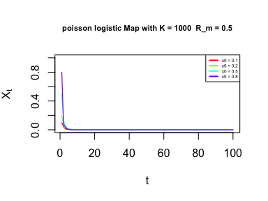

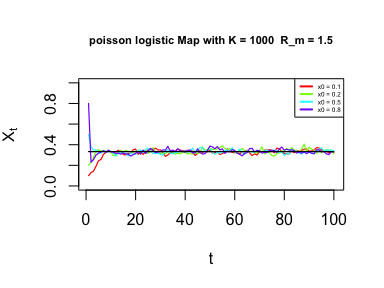

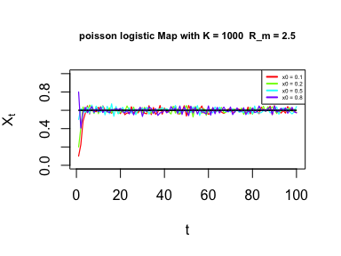

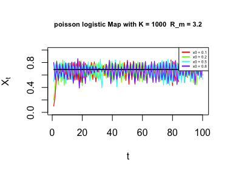

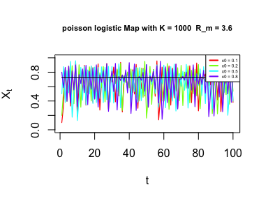

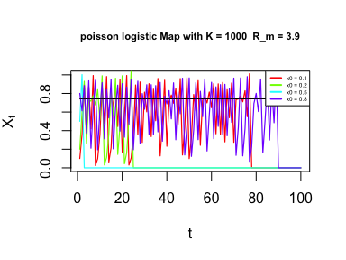

```r
plot_each_R_m_int(N_0_list = c(100, 200, 500, 800), R_m_list = c(0.5, 1.5, 2.5, 3.2,
              3.6, 3.9), K = 1000, time_steps = 100, distribution = "poisson")
```

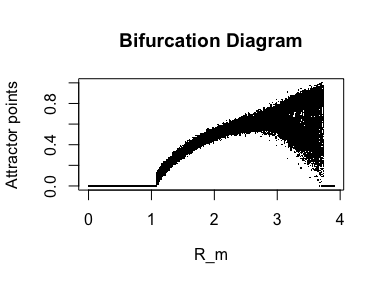

```r
Plot_Bifurcation_int(N_0 = 100, R_m_list = seq(0, 3.9, 0.01), K = 1000, time_steps =
                   1000, distribution = "poisson")
```